# Convergence of the chains

Muhammad Yaseen

2026-11-09

# 1 Abstract

Posterior summaries are valid only after the chains have reached their stationary distribution and are long enough. Crossa et al. (2011) used three diagnostics: Raftery and Lewis (1995), Heidelberger and Welch (1983) and Gelman and Rubin (1992). `bayes_ammi()` computes all three, together with effective sample sizes, through the package **coda**.

# 2 Several chains

```r
fit <-
  bayes_ammi(
      .data   = Maiz
    , .y      = y
    , .gen    = entry
    , .env    = site
    , .rep    = rep
    , .nIter  = 4000
    , .k      = 2
    , .burnin = 1000
    , .thin   = 1
    , .chains = 3
    , .priors = bam_priors(
          mu_mean     = 0
        , mu_var      = 1e+8
        , tau_mean    = 0
        , tau_var     = 1e+8
        , delta_mean  = 0
        , delta_var   = 1e+8
        , lambda_mean = 0
        , lambda_var  = 1e+8
        , nu          = 1
        , s2          = NULL
        )
    , .level  = 0.95
    , .seed   = 5
    , .align  = TRUE
    , .model  = "AMMI"
    , .het    = FALSE
    , .waic   = TRUE
    )
```

The first chain starts at the least-squares fit and the others at dispersed values (singular values scaled by factors between 0.5 and 1.5, perturbed scores, error variance scaled between 0.5 and 2).

# 3 Traces

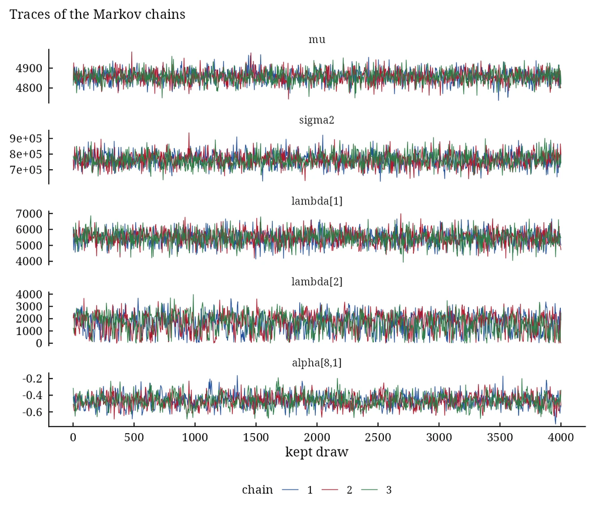

```r
plot(x = fit, which = "trace", pars = c("mu", "sigma2", "lambda[1]", "lambda[2]", "alpha[8,1]"))
```

# 4 Gelman-Rubin

The potential scale reduction factor compares the variance between chains with the variance within them. Values below 1.1 (better, 1.01) indicate that the chains have mixed.

```r
fit$diagnostics$gelman
```

```
Potential scale reduction factors:

          Point est. Upper C.I.
mu                 1          1
sigma2             1          1
tau[1]             1          1
tau[2]             1          1
tau[3]             1          1
tau[4]             1          1
tau[5]             1          1
tau[6]             1          1
tau[7]             1          1
tau[8]             1          1
tau[9]             1          1
delta[1]           1          1
delta[2]           1          1
delta[3]           1          1
delta[4]           1          1
delta[5]           1          1
delta[6]           1          1
delta[7]           1          1
delta[8]           1          1
delta[9]           1          1
delta[10]          1          1
delta[11]          1          1
delta[12]          1          1
delta[13]          1          1
delta[14]          1          1
delta[15]          1          1
delta[16]          1          1
delta[17]          1          1
delta[18]          1          1
delta[19]          1          1
delta[20]          1          1
lambda[1]          1          1
lambda[2]          1          1
```

```r
summary(object = fit$summary$rhat)
```

```
   Min. 1st Qu.  Median    Mean 3rd Qu.    Max.
 0.9999  1.0000  1.0002  1.0002  1.0004  1.0014
```

# 5 Raftery-Lewis

The dependence factor $I$ measures how much longer the chain must be than an independent sample of the same precision; $I > 5$ indicates strong autocorrelation.

```r
fit$diagnostics$raftery[[1]]
```

```
Quantile (q) = 0.025
Accuracy (r) = +/- 0.005
Probability (s) = 0.95

           Burn-in  Total Lower bound  Dependence
           (M)      (N)   (Nmin)       factor (I)
 mu        2        3866  3746         1.030
 sigma2    3        4374  3746         1.170
 tau[1]    2        3635  3746         0.970
 tau[2]    2        3711  3746         0.991
 tau[3]    2        3635  3746         0.970
 tau[4]    2        3787  3746         1.010
 tau[5]    2        3711  3746         0.991
 tau[6]    2        3711  3746         0.991
 tau[7]    2        3635  3746         0.970
 tau[8]    2        3635  3746         0.970
 tau[9]    2        3711  3746         0.991
 delta[1]  2        3711  3746         0.991
 delta[2]  2        3866  3746         1.030
 delta[3]  2        3787  3746         1.010
 delta[4]  2        3635  3746         0.970
 delta[5]  2        3561  3746         0.951
 delta[6]  2        3635  3746         0.970
 delta[7]  2        3946  3746         1.050
 delta[8]  2        3635  3746         0.970
 delta[9]  2        3787  3746         1.010
 delta[10] 2        3787  3746         1.010
 delta[11] 2        3711  3746         0.991
 delta[12] 2        3711  3746         0.991
 delta[13] 2        3635  3746         0.970
 delta[14] 2        3711  3746         0.991
 delta[15] 2        3711  3746         0.991
 delta[16] 2        3711  3746         0.991
 delta[17] 3        4120  3746         1.100
 delta[18] 2        3711  3746         0.991
 delta[19] 2        3635  3746         0.970
 delta[20] 2        3636  3746         0.971
 lambda[1] 2        3711  3746         0.991
 lambda[2] 8        9870  3746         2.630
```

# 6 Heidelberger-Welch

The stationarity test is applied to the whole chain, then after dropping the first 10%, 20%, … of it. The half-width test asks whether the mean is estimated precisely enough. Each test has level 0.05, so among many parameters a few failures are expected by chance.

```r
fit$diagnostics$heidel[[1]]
```

```
          Stationarity start     p-value
          test         iteration
mu        passed         1       0.2958
sigma2    passed         1       0.4442
tau[1]    passed         1       0.9243
tau[2]    passed         1       0.1717
tau[3]    passed         1       0.7242
tau[4]    passed         1       0.5047
tau[5]    passed         1       0.9581
tau[6]    passed         1       0.5442
tau[7]    passed         1       0.4945
tau[8]    passed         1       0.5535
tau[9]    passed         1       0.7765
delta[1]  passed         1       0.3812
delta[2]  passed         1       0.1691
delta[3]  passed         1       0.6711
delta[4]  passed         1       0.3446
delta[5]  passed         1       0.2919
delta[6]  passed         1       0.3637
delta[7]  passed         1       0.9329
delta[8]  passed         1       0.7061
delta[9]  passed         1       0.1740
delta[10] passed         1       0.4458
delta[11] passed       801       0.0677
delta[12] passed         1       0.9949
delta[13] passed         1       0.0578
delta[14] passed         1       0.2482
delta[15] passed         1       0.4003
delta[16] passed         1       0.3308
delta[17] passed         1       0.5631
delta[18] passed         1       0.1621
delta[19] passed         1       0.6172
delta[20] passed         1       0.4041
lambda[1] passed         1       0.2844
lambda[2] passed         1       0.4288

          Halfwidth Mean     Halfwidth
          test
mu        passed      4858.2    1.02
sigma2    passed    762251.7 1728.80
```

[output cut: 16 more lines]

```
delta[8]  passed      -829.7    4.39
delta[9]  passed       108.5    4.47
delta[10] passed     -1922.0    4.48
delta[11] passed       449.7    4.95
delta[12] passed      2661.4    4.41
delta[13] passed      1471.4    4.43
delta[14] passed      1191.0    4.46
delta[15] passed       191.5    4.33
delta[16] passed       545.5    4.27
delta[17] failed        21.7    4.41
delta[18] passed      -306.0    4.58
delta[19] passed     -2204.7    4.25
delta[20] failed       -19.2    4.23
lambda[1] passed      5464.0   15.56
lambda[2] passed      1644.9   67.79
```

# 7 Effective sample size and Monte Carlo error

```r
fit$summary[block %in% c("mu", "sigma2", "lambda"), list(parameter, mean, sd, mc_se, ess, rhat)]
```

```
   parameter       mean         sd       mc_se       ess      rhat
      <char>      <num>      <num>       <num>     <num>     <num>
1:        mu   4857.976    32.5537   0.2925239 12384.485 0.9999954
2:    sigma2 763066.073 43412.8267 500.5970862  7520.721 1.0002382
3: lambda[1]   5468.348   457.4447   4.6530521  9664.991 1.0003939
4: lambda[2]   1654.395   784.8158  21.0012922  1396.508 1.0000922
```

The Monte Carlo standard error `mc_se` is $\mathrm{sd}/\sqrt{\mathrm{ess}}$. Run longer chains when it is not small compared with the precision you need. The weak second singular value mixes more slowly than the other parameters.

# 8 The draws for further analysis

`fit$draws` is a `coda::mcmc.list`, so every function of **coda** applies:

```r
coda::autocorr.diag(mcmc.obj = fit$draws[, c("lambda[1]", "lambda[2]")], lags = c(1, 5, 10))
```

```
        lambda[1] lambda[2]
Lag 1  0.08931897 0.7099201
Lag 5  0.02070703 0.3129273
Lag 10 0.01404242 0.1274023
```

# 9 posterior and bayesplot

The draws also convert to a `draws_df` of **posterior**, which gives the rank-normalised $\widehat{R}$ and the bulk and tail effective sample sizes of Vehtari et al. (2021), and the plots of **bayesplot** take the `mcmc.list` directly (Gabry et al. 2019):

```r
dr <- posterior::as_draws_df(x = fit)
posterior::summarise_draws(
    .x = posterior::subset_draws(x = dr, variable = c("mu", "sigma2", "lambda[1]", "lambda[2]"))
  , "mean", "sd", "rhat", "ess_bulk", "ess_tail"
  )
```

```
# A tibble: 4 × 6
  variable     mean      sd  rhat ess_bulk ess_tail
  <chr>       <dbl>   <dbl> <dbl>    <dbl>    <dbl>
1 mu          4858.    32.6  1.00   11956.   12016.
2 sigma2    763066. 43413.   1.00    6507.    9830.
3 lambda[1]   5468.   457.   1.00    9062.   10658.
4 lambda[2]   1654.   785.   1.01    1242.    3663.
```

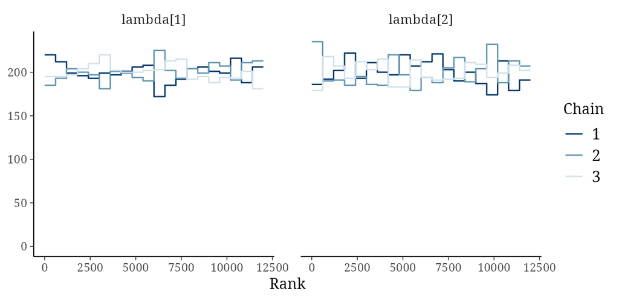

```r
bayesplot::mcmc_rank_overlay(x = fit$draws, pars = c("lambda[1]", "lambda[2]"))
```

Rank plots are flat and overlapping when the chains mix well.

# 10 Interpretation of convergence

```r
bam_interpret(
    x             = fit
  , higher_better = TRUE
  , top           = 5
  )$findings[1:2]
```

```
[1] "The chains have converged by the criteria of Crossa et al. (2011) (largest potential scale reduction factor 1.001); the smallest effective sample size of the main parameters is 1,400."
[2] "6 of 198 Heidelberger-Welch stationarity and half-width tests failed (about 5% fail by chance at level 0.05)."
```

# 11 References

Crossa, J., Perez-Elizalde, S., Jarquin, D., Cotes, J. M., Viele, K., Liu, G. and Cornelius, P. L. (2011). Bayesian estimation of the additive main effects and multiplicative interaction model. *Crop Science*, 51(4), 1458–1469. doi:10.2135/cropsci2010.06.0343

Gelman, A. and Rubin, D. B. (1992). Inference from iterative simulation using multiple sequences. *Statistical Science*, 7(4), 457–472.

Raftery, A. E. and Lewis, S. M. (1995). The number of iterations, convergence diagnostics and generic Metropolis algorithms. In W. R. Gilks, D. J. Spiegelhalter and S. Richardson (eds), *Practical Markov Chain Monte Carlo*. Chapman and Hall, London.

Heidelberger, P. and Welch, P. D. (1983). Simulation run length control in the presence of an initial transient. *Operations Research*, 31(6), 1109–1144.

Plummer, M., Best, N., Cowles, K. and Vines, K. (2006). CODA: convergence diagnosis and output analysis for MCMC. *R News*, 6(1), 7–11.

Vehtari, A., Gelman, A., Simpson, D., Carpenter, B. and Burkner, P.-C. (2021). Rank-normalization, folding, and localization: an improved R-hat for assessing convergence of MCMC. *Bayesian Analysis*, 16(2), 667–718.

Gabry, J., Simpson, D., Vehtari, A., Betancourt, M. and Gelman, A. (2019). Visualization in Bayesian workflow. *Journal of the Royal Statistical Society A*, 182(2), 389–402.